# ECON 320 — Econometrics Lab

## ⬇️ Exercise 3 — Import *one* dataset into Python

Choose **one** dataset (not necessarily your final choice) and import it.

💡 Tip: Ask an LLM for the exact import steps. Example prompt:

> **How to import file type `_____` into a pandas DataFrame in Python?**

Replace the blank with the file type (CSV, Excel, JSON, Parquet, etc.).

```python
# Replace with your path and loader
data_path = 'PATH/TO/YOUR/DATAFILE'  # e.g., 'data/myfile.csv'


# df = pd.read_csv(data_path)
df = pd.read_excel("data.xlsx")

df.head() if isinstance(df, pd.DataFrame) else 'Load your data into df first.'
```

|  | Year | Jan | Feb | Mar | Apr | May | Jun | Jul | Aug | Sep | Oct | Nov | Dec | HALF1 | HALF2 |
| --- | --- | --- | --- | --- | --- | --- | --- | --- | --- | --- | --- | --- | --- | --- | --- |
| 0 | 2015 | 246.100 | 246.269 | 245.689 | 245.746 | 245.846 | 246.245 | 246.558 | 247.196 | 248.090 | 248.575 | 247.870 | 247.468 | 245.983 | 247.626 |
| 1 | 2016 | 248.241 | 248.459 | 247.677 | 248.095 | 247.580 | 247.207 | 247.267 | 247.420 | 247.645 | 247.861 | 247.246 | 247.134 | 247.877 | 247.429 |
| 2 | 2017 | 248.074 | 248.595 | 248.967 | 249.538 | 249.749 | 249.398 | 249.930 | 250.212 | 250.735 | 251.130 | 250.694 | 251.024 | 249.054 | 250.621 |
| 3 | 2018 | 252.109 | 252.076 | 252.182 | 252.999 | 252.848 | 253.022 | 253.476 | 253.779 | 254.178 | 254.203 | 254.262 | 255.023 | 252.539 | 254.154 |
| 4 | 2019 | 256.185 | 256.997 | 257.430 | 257.393 | 257.791 | 257.778 | 258.015 | 258.154 | 258.646 | 259.284 | 259.080 | 259.403 | 257.262 | 258.764 |

## 📊 Exercise 4 — Summary stats & visuals (Y vs X)

From `df`, select **one outcome (Y)** and **one predictor (X)**, then:

1. Print `.describe()` for these variables.
2. Plot a histogram for **Y** and a histogram for **X**.
3. Plot a scatter of **Y vs X**.

*This choice does not have to be final for the project.*

```
Summary stats for Y (Dec CPI):
count     10.000000
mean     278.319500
std       32.920905
min      247.134000
25%      252.023750
50%      264.393000
75%      307.233250
max      330.812000
Name: Dec, dtype: float64

Summary stats for X (Year):
count      11.000000
mean     2020.000000
std         3.316625
min      2015.000000
25%      2017.500000
50%      2020.000000
75%      2022.500000
max      2025.000000
Name: Year, dtype: float64
```

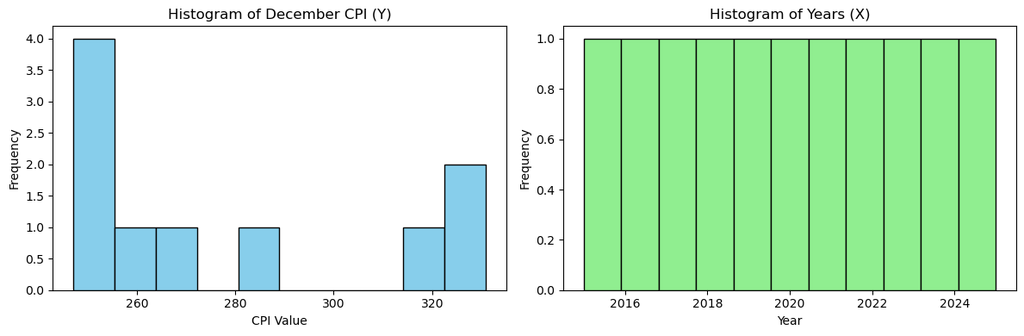

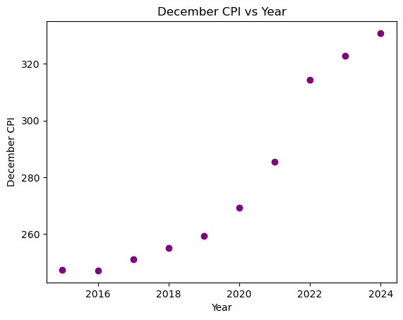

```python
# your code here
import matplotlib.pyplot as plt

# Example choice:
#   Y = Dec (CPI in December each year)
#   X = Year

Y = df["Dec"]
X = df["Year"]

# 1. Summary stats
print("Summary stats for Y (Dec CPI):")
print(Y.describe())
print("\nSummary stats for X (Year):")
print(X.describe())

# 2. Histograms
plt.figure(figsize=(12,4))

plt.subplot(1,2,1)
plt.hist(Y, bins=10, color="skyblue", edgecolor="black")
plt.title("Histogram of December CPI (Y)")
plt.xlabel("CPI Value")
plt.ylabel("Frequency")

plt.subplot(1,2,2)
plt.hist(X, bins=len(X), color="lightgreen", edgecolor="black")
plt.title("Histogram of Years (X)")
plt.xlabel("Year")
plt.ylabel("Frequency")

plt.tight_layout()
plt.show()

# 3. Scatter plot
plt.scatter(X, Y, color="purple")
plt.title("December CPI vs Year")
plt.xlabel("Year")
plt.ylabel("December CPI")
plt.show()
```

## 📝 Exercise 5 — One‑page research proposal (LaTeX **or** Word)

**Due:** **October 8, 2025**.

Write **one page** describing your research idea. Use the guidelines in the **course resource HTML** provided.

**Include:** research question (who/where/when/outcome/exposure), data source(s) & access plan, proposed econometric approach, expected challenges.

Upload a PDF to the Canvas assignment tab (export from LaTeX or Word).

### ✅ Checklist

- Group of 3–5 with lab in parentheses
- Five candidate datasets + one‑line ideas
- One dataset imported into Python
- Summary stats + histograms + scatter (Y vs X)
- One‑page proposal drafted per guidelines

ECON320 Python Programming Laboratory

Instructor *Guido Anthony Romero*

*guido.romero@emory.edu*

Department of Economics

Emory University